# Recipe Project Report

## Marayah Ayoub-Schreifeldt

### Description:

This program will help you try new recipes with the ingredients of your choice! List the ingredients that you'd like to use, and this program will show you all recipes from a database of 350.000 recipes that include those ingredients. If you list very few ingredients, the recipes shown may include some things you did not input. But the top recipes shown, will be the ones with the least amount of additional ingredients needed.

### Usage:

If used outside of the 'programming next steps' course, please make a spoonacular account inorder to receive your own api key from https://spoonacular.com/food-api and replace it before running the program under api_key = .

In order to run the program you need to install the spoonacular API using pip ($pip install spoonacular). You must also have an internet connection and import PysimpleGUI and webbrowser (found at the top of the program code).

When running the code a window will open in which the user can input the ingredients they have available. Please make sure to seperate each ingredient with a comma and to make sure all are spelled correctly. See the first window below:

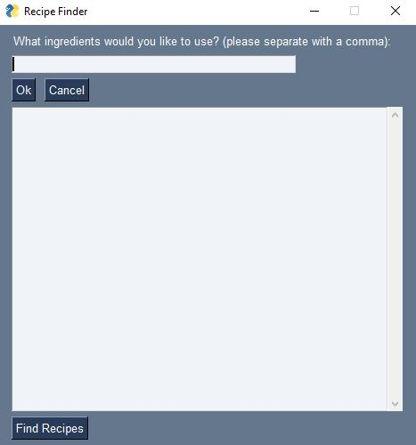

By clicking 'ok' in the widow, the program works with the API, to find the top 10 recipes which include the input ingredients. The 10 recipes shown are the ones which either only include the input inredients, or have the least amount of additional ingredients required. The window in which you can see and select recipes looks as follows:

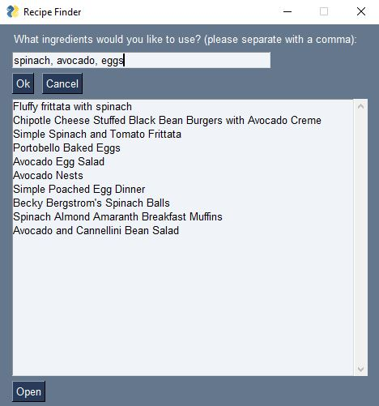

### Understanding the code:

The layout_window () defines the layout and style of the main_window.

The main_loop() function (see below) takes the user's input from the GUI main window and works with the 'find_recipes()' function to display the available recipes and the link associated with the user's recipe choice.

```python
    while True:
        event, values = window.read()
        if event == sg.WIN_CLOSED or event == 'Cancel':
            break
        elif event == 'Ok':
            ingredients = values[0]
            recipes_dict = find_recipes(ingredients)
            window['-OUTPUT-'].update(list(recipes_dict.keys()))
        if event == 'Open':
            chosen = values['-OUTPUT-'][0]
            chosen_id = recipes_dict[chosen]
            recipe_link(chosen_id)
```

The find_recipes(ingredients) function communicates with the API to find the recipes based on the input ingredients. It defines the way the recipes are chosen ('ranking = ') which has been put to 1. This tells the API to choose the top 10 ingredients with the smallest amount of additional ingredients. Find the find_recipes(ingredients) code below:

```python
response = api.search_recipes_by_ingredients(ingredients, ranking=1)
    api.search_recipes_by_ingredients(ingredients)
    data = response.json()
    recipe_name = []
    recipe_id = []

    for i in range(len(data)):
        recipe_name += [data[i]['title']]
        recipe_id += [data[i]['id']]
    recipe_dict = dict(zip(recipe_name, recipe_id))
    return recipe_dict
```

The last function recipe_link(id) opens the link that is associated with the chosen recipe. This is done through the recipe ID. The link will open in the user's browser. Find the recipe_link(id) code below:

```python
response = api.get_recipe_information(id)
    data = response.json()
    wb.open((data['sourceUrl']))
    return data['sourceUrl']
```